# Clinical data analysis

Roman Susdorf

November 14, 2018

# Introduction

In this session I will analyse a fictional data set describing the severity-state (numerical) of patients suffering from a disease. The patients received 4 different treatments (Placebo, Treatment X, Y and Z), and their severity-state is monitored over a period of 24 months with observations made at the start of treatment (month 0), and then 6, 12 and 24 months later. We have information on the *age* and *gender* of participants, as well as the time since they were diagnosed with the disease (in years).

First of all, the data in csv-format are imported from GitHub using the *RCurl* library:

```r
library(RCurl)
data <-read.csv(text=getURL("https://raw.githubusercontent.com/romsus/epi/master/treatment.csv"), header=T)
head(data)
```

```
##   ID gender age treatment.arm time.since.diagnosis severity.month0
## 1  1 Female  38    TreatmentY                    8        8.204057
## 2  2   Male  61    TreatmentX                    6        3.965637
## 3  3 Female  46       Placebo                    5       11.245326
## 4  4   Male  47    TreatmentX                    5        7.067952
## 5  5   Male  51    TreatmentY                    0        6.704536
## 6  6 Female  45    TreatmentY                    3       17.680828
##   severity.month6 severity.month12 severity.month24
## 1              NA               NA               NA
## 2        12.52753               NA               NA
## 3        17.43760         21.07843         23.92292
## 4        13.53328         15.20796         16.63206
## 5              NA               NA               NA
## 6        21.23299         23.56689         25.73141
```

# Data manipulation and descriptive statistical analysis

Some of the variable names are long and tedious to write. So they will be amended for easier handling:

```r
# change variable names for severity observations at intervals month 0, 6, 12 and 24
colnames(data)[6:9]<-c("m0","m6", "m12", "m24")
# change column name from treatment.arm to treatment
colnames(data)[4]<-"treatment"
table(data$treatment) # it seems that one observation is faulty (NA for treatment):
```

```
##
##               Placebo TreatmentX TreatmentY TreatmentZ
##          1         66         64         61         16
```

```r
# change treatment names
levels(data$treatment)<-c("NA","Pl","X","Y","Z")
# remove the row with NA for treatment:
data<-data[data$treatment!="NA",]

# then readjust treatment levels to get rid of the NA-level:
data$treatment<-factor(data$treatment)
table(data$treatment)
```

```
##
## Pl  X  Y  Z
## 66 64 61 16
```

Then it is useful to have a look at the course of disease severity over time for different *treatment* arms. For easy handling and plotting, the data are transformed into long format using the *tidyr* package. All entries from the columns for severity (m0, m6, m12 and m24) are then gathered in a single column named *severity*. The other new column *time_lag* contains the month when the corresponding *severity* observation was made, i.e. m0, m6, m12 or m24:

```r
library(tidyr)
data_long <- gather(data, time_lag, severity, m0:m24, factor_key=TRUE)
head(data_long,7)
```

```
##   ID gender age treatment time.since.diagnosis time_lag  severity
## 1  1 Female  38         Y                    8       m0  8.204057
## 2  2   Male  61         X                    6       m0  3.965637
## 3  3 Female  46        Pl                    5       m0 11.245326
## 4  4   Male  47         X                    5       m0  7.067952
## 5  5   Male  51         Y                    0       m0  6.704536
## 6  6 Female  45         Y                    3       m0 17.680828
## 7  7   Male  57        Pl                    5       m0 17.980496
```

Now I will use boxplots to show the severity distributions for each treatment arm over time from the start of clinical trial (Plot 1)

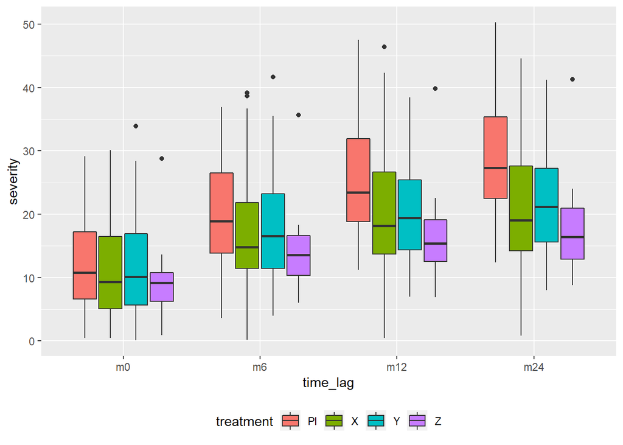

```r
par(mfrow=c(2,1),mgp=c(1.5,0.4,0), tck=-0.008,omi=c(0,0,0.05,0.05), mai=c(1.5,0.3,0,0),cex=0.8, cex.axis=1,cex.main=0.8)
library(ggplot2)
ggplot(data_long, aes(x=time_lag, y=severity, fill=treatment)) +
  geom_boxplot() +
  theme(legend.position="bottom")
```

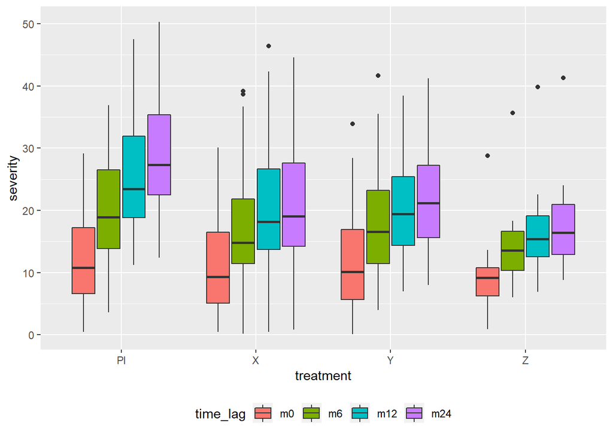

```r
ggplot(data_long, aes(x=treatment, y=severity, fill=time_lag)) +
  geom_boxplot() +
  theme(legend.position="bottom")
```

The boxplots show the median value and the boxes cover a interquartile-range of 1.5. If you are interested in the mean values (for any peculiar reason), you can easily obtain them using the *mosaic* package as shown below:

```r
library(mosaic)
# make a table with the means of severity as a function of treatment and time from the start of clinical trial
mean_sev<-mean(~severity, treatment+time_lag, data=data_long, na.rm=T)
# xlab names for treatment and time since trial
median_sev<-median(~severity, treatment+time_lag, data=data_long, na.rm=T)
# make a dataframe for plotting in ggplot2
meddf<-data.frame(median_severity=as.numeric(median_sev),
                  treatment=rep(levels(data_long$treatment), length(levels(data_long$time_lag))),
                  time_lag=rep(levels(data_long$time_lag),each=4))
```

We can plot the median severity (out-commented *geom_point* function in the code-chunk below) and add a curve depicting severity progression over time for each treatment group:

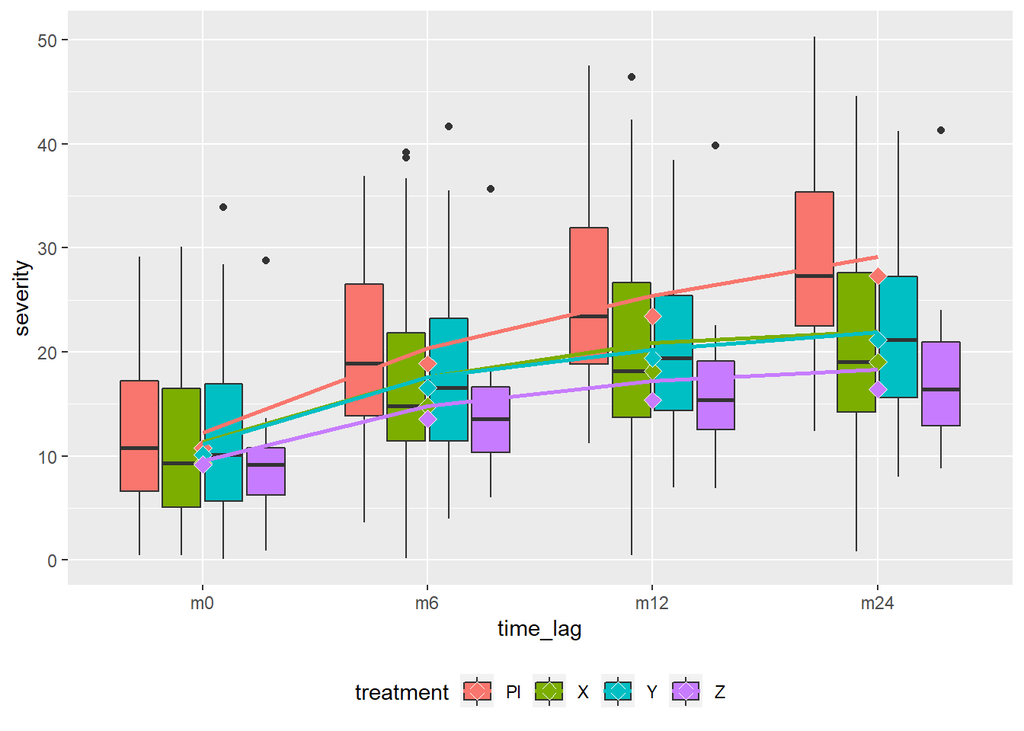

```r
ggplot(data_long, aes(x=time_lag, y=severity, fill=treatment)) +
  geom_boxplot() +
  theme(legend.position="bottom") +
  #stat_summary(fun.y=median, geom="line", aes(group=4))  +
  geom_point(aes(x=time_lag, y=median_severity, fill=treatment),data=meddf, size=3, col="white", shape=23) +
  geom_smooth(aes(group = treatment, col=treatment), method="auto", se = F)
```

We also could overlay the boxplot with severity trajectories for each individual *ID*

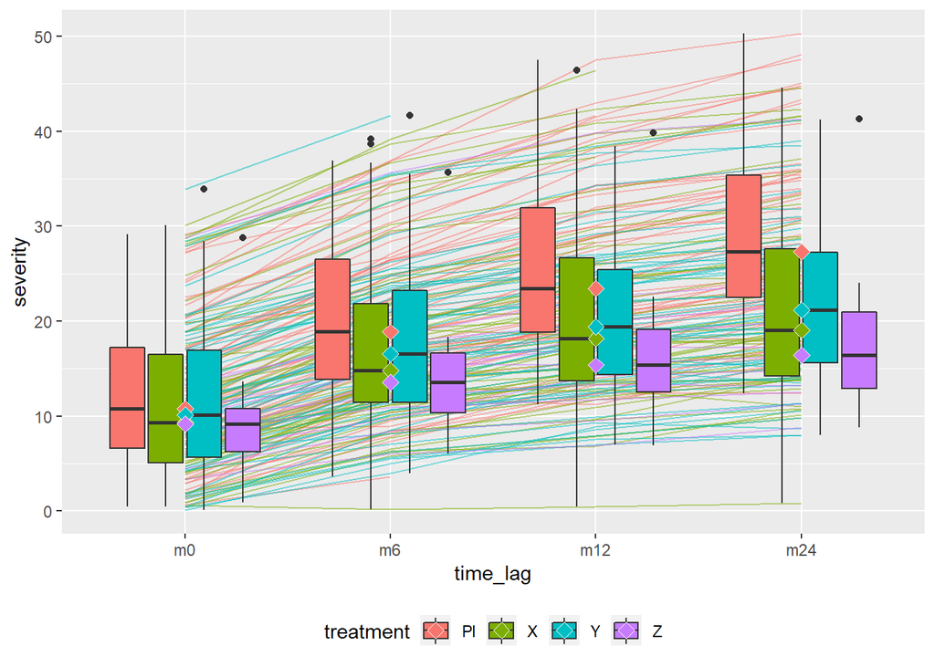

```r
ggplot(data_long, aes(x=time_lag, y=severity, fill=treatment)) +
  theme(legend.position="bottom") +
geom_line(aes(group = interaction(ID, treatment), colour=treatment),data=data_long,alpha = 0.5) +
  geom_boxplot() +
geom_point(aes(x=time_lag, y=median_severity, fill=treatment),data=meddf, size=3, col="white", shape=23)
```

Let’s assume, we wanted to consider each patient’s time from diagnosis (*time.since.diagnosis*) which is assigned in the data in years. We could for example plot each severity progress trajectory adjusted by the time the patient has been diagnosed.  
Note: time from diagnosis is given in years, severity scores are measured over months

Therefore a new variable (*tsd_mo*) is created which shall contain the severity scores with the number of months since diagnosis:

```r
# first rename time.since.diagnosis to tsd:
colnames(data_long)[which(colnames(data_long)=="time.since.diagnosis")]<-"tsd"
data_long$tsd_mo<-data_long$tsd*12+c(0,6,12,24)[as.numeric(data_long$time_lag)]
# check whether it is correct:
data_long[seq(1,500,6),]
```

```
##      ID gender age treatment tsd time_lag   severity tsd_mo
## 1     1 Female  38         Y   8       m0  8.2040574     96
## 7     7   Male  57        Pl   5       m0 17.9804956     60
## 13   13   Male  49         X  18       m0 14.5078686    216
## 19   19 Female  43         X  15       m0 24.8445734    180
## 25   25 Female  55         X   0       m0  3.3206446      0
## 31   31   Male  45        Pl   0       m0 14.9258206      0
## 37   37 Female  55         Y   0       m0  0.3637056      0
## 43   43 Female  34         X   0       m0  0.6505290      0
## 49   49 Female  40        Pl   0       m0 10.0553792      0
## 55   55   Male  48         X   4       m0 20.5687096     48
## 61   61 Female  48        Pl   0       m0 10.0790413      0
## 67   67   Male  49        Pl  15       m0 10.6173609    180
## 73   73 Female  50         Y   6       m0  5.9791124     72
## 79   79 Female  33        Pl   5       m0 19.8346618     60
```

[output cut: 70 more lines]

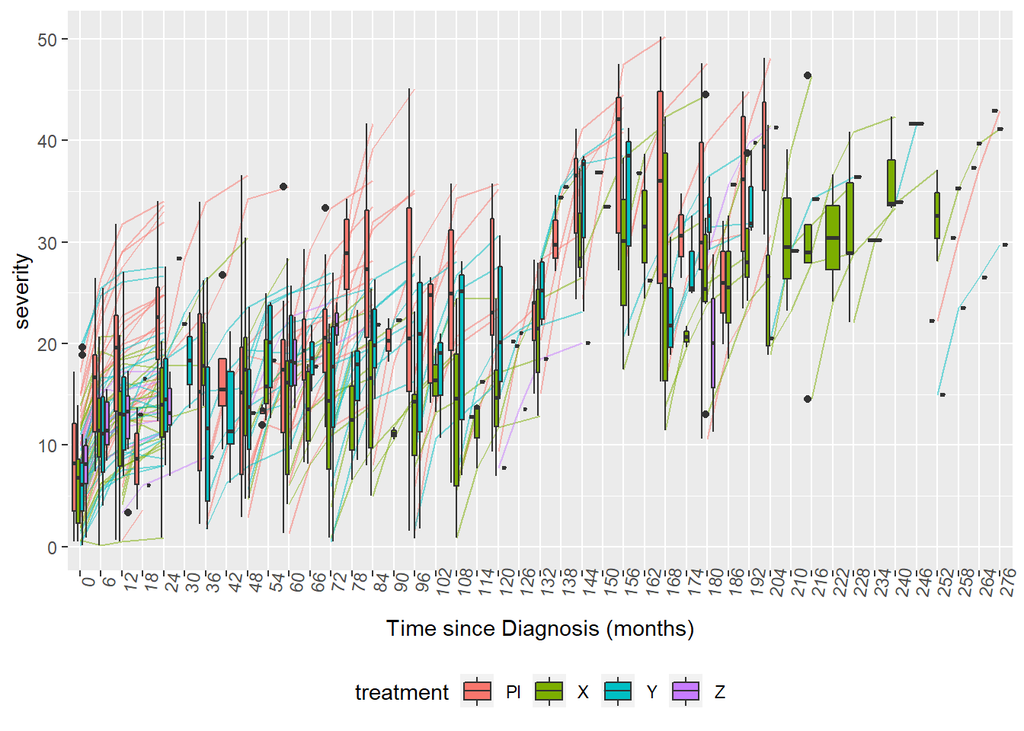

```r
ggplot(data_long, aes(x=as.factor(tsd_mo), y=severity, fill=treatment)) +
  theme(legend.position="bottom") +
geom_line(aes(group = interaction(ID, treatment), colour=treatment),data=data_long,alpha = 0.5) +
  geom_boxplot() +
  xlab("Time since Diagnosis (months)") +
  theme(axis.text.x = element_text(angle=80))
```

We could calculate cumulative disease severity (sum over all available disease severity) for each patient and plot a boxplot for each treatment arm.

First of all, it makes sense to get rid of all incomplete severity observations. I call the new reduced data set *d_red*.

```r
length(data_long$severity)-length(na.omit(data_long$severity)) # 101 NA's in severity
```

```
## [1] 101
```

```r
d_red<-data_long[!is.na(data_long$severity),] # 727 remaining rows is correct
```

To conveniently calculate the cumulative *severity*, a wide format data frame is created and the new variabe *cum_sum* added:

```r
d_red_wide<-data[complete.cases(data[,c(6:9)]),] # remove NAs
d_red_wide$cum_sum<-apply(d_red_wide[,c(6:9)],1,sum, na.rm=T) # calculate cumulative severity
```

The results can be plotted using *ggplot*:

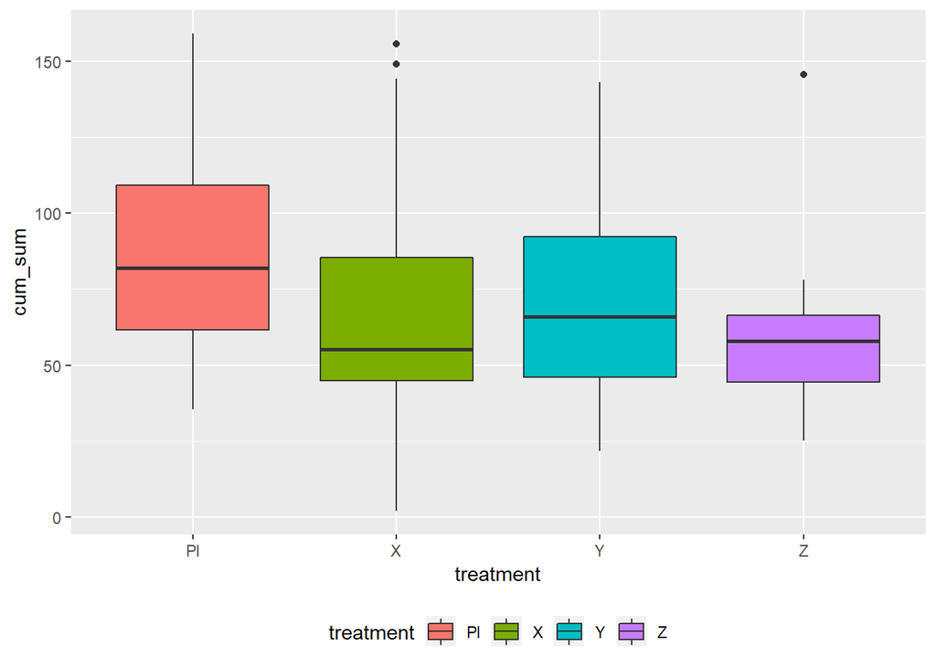

```r
library(ggplot2)
ggplot(d_red_wide, aes(x = treatment, y=cum_sum, fill = treatment)) +
  geom_boxplot() +
  theme(legend.position="bottom")
```

# Post-hoc statistical analysis

Now we can assess the contribution of each treatment on severity at each sampling interval (at 0, 6, 12 and 24 months) using **ANOVA**. Before we start, I want to compute the homogeneity of variance using **Levene’s test** (*car* package) across treatments. If the data would show signs of heteroscedasticity, alternative options could be for example **Kruskall_Wallis test** or **Welch ANOVA**.  
For each time interval *time_lag* I will run the **Levene’s test** and store the corresponding p-value in vector *lev.p*:

```r
lev.p<-data.frame(time=rep(NA,4), p=rep(NA,4))
library(car)
for (i in 1:length(levels(d_red$time_lag))){
lev.p[i,2]<-leveneTest(severity ~ treatment, data=d_red[d_red$time_lag==levels(d_red$time_lag)[i],])$`Pr(>F)`[1]
lev.p[i,1]<-levels(d_red$time_lag)[i]}
options(scipen=999)
lev.p
```

```
##   time         p
## 1   m0 0.2458128
## 2   m6 0.7078456
## 3  m12 0.3621956
## 4  m24 0.4937090
```

The **Levene’s test** suggests that severity variance between treatments accross *time_lag* is homogeneous. Thus **ANOVA** is a reasonable option in this case.

## ANOVA

We assess whether *treatment* has an effect on *severity* using **ANOVA**. A potential influence of variables *time_lag*, *gender* or *age* on the effect from *treatment* (i.e. interaction) will assessed.

First of all, a preliminary analysis is conducted: the effect of *treatment* at each sampling intervall is assessed using **Tukey’s honest significance test**. To obtain a data frame in the temporal order m0,m6,m12 and m24, the *time_lag* level *m6* will be renamed to *m06*. I will only look at the effects within a sampling interval *time_lag*. Therefore, only a subset of the data frame (*tuk*) is shown below:

```r
levels(d_red$time_lag)[levels(d_red$time_lag)=="m6"]<-"m06"
tuk<-TukeyHSD(aov(severity ~ time_lag*treatment  + gender, data=d_red))[[4]]
tuk<-tuk[order(rownames(tuk)),][c(1,5,6, 13,14,15,    28,34,35, 44,45,46,    59,67,68, 79,80,81,  94,104,105,118,119,120),]
```

A plot with 95% confidence intervals of the differences between each *treatment* provides a nice overview:

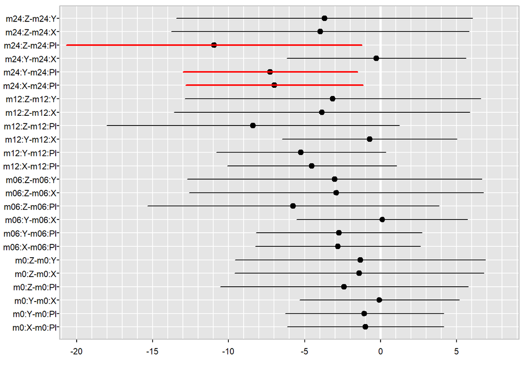

```r
# Function to add transparency to base colours:
add.alpha <- function(col, alpha=1){
  if(missing(col))
    stop("Please provide a vector of colours.")
  apply(sapply(col, col2rgb)/255, 2,
        function(x)
          rgb(x[1], x[2], x[3], alpha=alpha))}

# Tukey Plot:
par(mfrow=c(1,1),  mgp=c(1,0.2,0), tck=-0.008,omi=c(0.45,0.8,0.08,0.05), mai=c(0,0,0.0,0), cex=1, cex.axis=0.7)
plot(y=c(1:length(rownames(tuk))),x=as.numeric(tuk[,1]),col=1, yaxt="n", ylab="treatment x time", xlab="Severity difference", xlim=c(-20,8))
polygon(x=c(-10000,-10000,50000,50000),y=c(-500,50000,50000,-500),col=add.alpha(1,0.1),border=NA)
abline(v=seq(-100,100, 1), col='white')
abline(h=seq(0, 10000, 1), col='white')
abline(v=0, lwd=3, col='white')
points(y=c(1:length(rownames(tuk))),x=as.numeric(tuk[,1]), pch=16)
for (i in 1:nrow(tuk)){lines(y=rep(i,2), x=as.numeric(tuk[i,c(2,3)]), col=ifelse(as.numeric(tuk[i,c(3)])>0, 1, 2), lwd=ifelse(as.numeric(tuk[i,c(3)])>0, 1, 2))}
axis(2, at=seq(1,nrow(tuk),1), labels=rownames(tuk), las=1)
box(lty=1, col="grey75")
```

It seems that an effect of *treatment X*, *Y* and *Z* is only evident at the 24 month sampling interval (red lines). *Z* has the greatest effect reducing *severity* by mean 11. However, due to the relatively small sample size of *treatment*-class *Z*, the 95% confidence interval is relatively wide.

## Model fit

However, a formal model selection should be carried out. A linear model will be used.

Imbalance is not defined formally. Often a sample size ratio of 1:10 between classes is considered being imbalanced. Therefore, our data is balanced enough as shown in the *replications* function:

```r
d_red$gender<-factor(d_red$gender)
replications(severity ~ treatment + time_lag + gender, data=d_red)
```

```
## $treatment
## treatment
##  Pl   X   Y   Z
## 241 219 218  49
##
## $time_lag
## time_lag
##  m0 m06 m12 m24
## 207 182 174 164
##
## $gender
## gender
## Female   Male
##    243    484
```

Thus, we will compare each candidate model using **type I ANOVA**:

```r
m1<-lm(severity ~ treatment + time_lag + gender + age  + tsd , data=d_red)
anova(m1, update(m1, .~. -age)) # p>0.8 means we cannot reject the Null-hypothesis that there is no age-effect. I.e. evidence suggests that there is no influence of age on severity in the model.
```

```
## Analysis of Variance Table
##
## Model 1: severity ~ treatment + time_lag + gender + age + tsd
## Model 2: severity ~ treatment + time_lag + gender + tsd
##   Res.Df   RSS Df Sum of Sq     F Pr(>F)
## 1    717 27950
## 2    718 27951 -1   -1.2863 0.033 0.8559
```

```r
# New model m1
m1<-update(m1, .~. -age)
summary(m1)
```

```
##
## Call:
## lm(formula = severity ~ treatment + time_lag + gender + tsd,
##     data = d_red)
##
## Residuals:
##      Min       1Q   Median       3Q      Max
## -16.5412  -4.7125  -0.1751   3.8455  18.0672
##
## Coefficients:
##             Estimate Std. Error t value             Pr(>|t|)
## (Intercept)  6.98082    0.67437  10.352 < 0.0000000000000002 ***
## treatmentX  -4.84062    0.58991  -8.206  0.00000000000000106 ***
## treatmentY  -3.59404    0.58349  -6.160  0.00000000121417385 ***
## treatmentZ  -4.60339    0.98252  -4.685  0.00000334414145996 ***
## time_lagm06  6.71190    0.63426  10.582 < 0.0000000000000002 ***
## time_lagm12 10.40139    0.64193  16.203 < 0.0000000000000002 ***
## time_lagm24 12.46090    0.65242  19.100 < 0.0000000000000002 ***
## genderMale   2.62726    0.49711   5.285  0.00000016690011043 ***
## tsd          1.06271    0.04229  25.131 < 0.0000000000000002 ***
## ---
## Signif. codes:  0 '***' 0.001 '**' 0.01 '*' 0.05 '.' 0.1 ' ' 1
##
## Residual standard error: 6.239 on 718 degrees of freedom
## Multiple R-squared:  0.6293, Adjusted R-squared:  0.6252
## F-statistic: 152.4 on 8 and 718 DF,  p-value: < 0.00000000000000022
```

```r
m2<-update(m1, .~. +treatment:time_lag)
anova(m2,m1) # F>2.5, p=0.00607 means we can reject the Null-hypothesis that there is no interaction between treatment and time_lag. I.e. interaction is evident.
```

```
## Analysis of Variance Table
##
## Model 1: severity ~ treatment + time_lag + gender + tsd + treatment:time_lag
## Model 2: severity ~ treatment + time_lag + gender + tsd
##   Res.Df   RSS Df Sum of Sq     F   Pr(>F)
## 1    709 27061
## 2    718 27951 -9   -890.04 2.591 0.006071 **
## ---
## Signif. codes:  0 '***' 0.001 '**' 0.01 '*' 0.05 '.' 0.1 ' ' 1
```

```r
m3<-update(m2, .~. +treatment:gender)
anova(m3,m2) # F>3, p=0.0267 means we can reject the Null-hypothesis that there is no interaction between treatment and gender. I.e. their  interaction is evident.
```

```
## Analysis of Variance Table
##
## Model 1: severity ~ treatment + time_lag + gender + tsd + treatment:time_lag +
##     treatment:gender
## Model 2: severity ~ treatment + time_lag + gender + tsd + treatment:time_lag
##   Res.Df   RSS Df Sum of Sq      F Pr(>F)
## 1    706 26711
## 2    709 27061 -3   -350.26 3.0859 0.0267 *
## ---
## Signif. codes:  0 '***' 0.001 '**' 0.01 '*' 0.05 '.' 0.1 ' ' 1
```

```r
m4<-update(m3, .~. +treatment:age)
anova(m4,m3) # F=0.9038, p=0.4612 means we cannot reject the Null-hypothesis that there is no interaction between treatment and age. I.e. their interaction is not evident.
```

```
## Analysis of Variance Table
##
## Model 1: severity ~ treatment + time_lag + gender + tsd + treatment:time_lag +
##     treatment:gender + treatment:age
## Model 2: severity ~ treatment + time_lag + gender + tsd + treatment:time_lag +
##     treatment:gender
##   Res.Df   RSS Df Sum of Sq      F Pr(>F)
## 1    702 26574
## 2    706 26711 -4   -136.85 0.9038 0.4612
```

```r
m5<-update(m3, .~. +treatment:tsd)
anova(m5,m3) # F=0.0371, p=0.9904 means we cannot reject the Null-hypothesis that there is no interaction between treatment and tsd (time since diagnosis in years). I.e. their interaction is not evident.
```

```
## Analysis of Variance Table
##
## Model 1: severity ~ treatment + time_lag + gender + tsd + treatment:time_lag +
##     treatment:gender + treatment:tsd
## Model 2: severity ~ treatment + time_lag + gender + tsd + treatment:time_lag +
##     treatment:gender
##   Res.Df   RSS Df Sum of Sq      F Pr(>F)
## 1    703 26707
## 2    706 26711 -3   -4.2323 0.0371 0.9904
```

If our data would be more unbalanced, we would use **type II or III ANOVA** instead. In our case the results are essentially the same regardless of **ANOVA** type:

```r
Anova(m2, type="III") # p=0.006071
```

```
## Anova Table (Type III tests)
##
## Response: severity
##                     Sum Sq  Df  F value                Pr(>F)
## (Intercept)         1341.5   1  35.1460        0.000000004776 ***
## treatment            162.5   3   1.4192              0.235902
## time_lag            9533.4   3  83.2579 < 0.00000000000000022 ***
## gender              1082.5   1  28.3603        0.000000135348 ***
## tsd                24516.7   1 642.3305 < 0.00000000000000022 ***
## treatment:time_lag   890.0   9   2.5910              0.006071 **
## Residuals          27061.3 709
## ---
## Signif. codes:  0 '***' 0.001 '**' 0.01 '*' 0.05 '.' 0.1 ' ' 1
```

```r
Anova(m3, type="III") # p=0.026698
```

```
## Anova Table (Type III tests)
##
## Response: severity
##                     Sum Sq  Df  F value                Pr(>F)
## (Intercept)         1662.5   1  43.9419      0.00000000006721 ***
## treatment            386.4   3   3.4045              0.017354 *
## time_lag            9586.9   3  84.4639 < 0.00000000000000022 ***
## gender                11.4   1   0.3024              0.582577
## tsd                24628.2   1 650.9481 < 0.00000000000000022 ***
## treatment:time_lag   919.7   9   2.7009              0.004274 **
## treatment:gender     350.3   3   3.0859              0.026698 *
## Residuals          26711.1 706
## ---
## Signif. codes:  0 '***' 0.001 '**' 0.01 '*' 0.05 '.' 0.1 ' ' 1
```

```r
Anova(m4, type="III") # p=0.4612
```

```
## Anova Table (Type III tests)
##
## Response: severity
##                     Sum Sq  Df  F value               Pr(>F)
## (Intercept)          262.8   1   6.9410              0.00861 **
## treatment            222.2   3   1.9567              0.11916
## time_lag            9583.9   3  84.3912 < 0.0000000000000002 ***
## gender                 6.6   1   0.1757              0.67526
## tsd                23128.2   1 610.9678 < 0.0000000000000002 ***
## treatment:time_lag   903.4   9   2.6516              0.00501 **
## treatment:gender     320.2   3   2.8196              0.03818 *
## treatment:age        136.9   4   0.9038              0.46119
## Residuals          26574.2 702
## ---
## Signif. codes:  0 '***' 0.001 '**' 0.01 '*' 0.05 '.' 0.1 ' ' 1
```

We will progress with linear model **m3** which considers main effects as well as interaction between *treatment* with *time_lag* and also *gender*. The model explains 63.5% variation in the data (*adjusted Pearson’s R-squared*). In the next step linear model assumptions (normally distributed residuals, homoscedasticity etc) are assessed using plots.

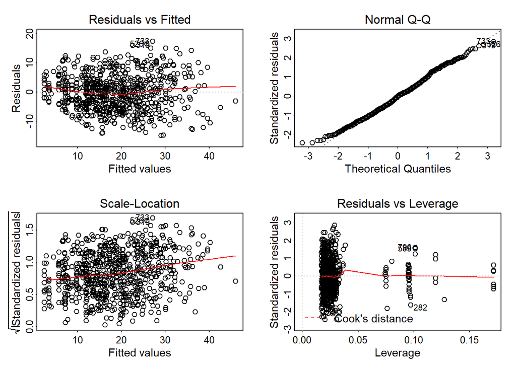

```r
par(mfrow=c(2,2),mgp=c(1.1,0.1,0), tck=-0.008,omi=c(0,0,0,0), mai=c(0.5,0.5,0.4,0.2), cex=0.9, cex.axis=0.9,cex.main=0.9)
plot(m3)
```

These plots look good. No coarse deviations from Normality or non-constant variance. The model *m3* is used to simulate *severity* given certain patient characteristics.

# Simulation

```r
pred_dat<-expand.grid(treatment=c("Pl","X","Y","Z"), time_lag=unique(d_red$time_lag), gender=c("Female","Male"), tsd=seq(1,4,1)) # The data frame containing relevant variables
pred_mat<-matrix(NA, nrow=nrow(pred_dat), ncol=500) # 500 severity values will be simulated for each row in pred_dat
```

Now the mean and 95% prediction intervals will be predicted using linear model *m3* with variables given in each row of *pred_dat*. These are stored in *xx*, and used to sample from the corresponding Normal distribution.

```r
for(i in 1:nrow(pred_mat)){
xx<-predict(m3, newdata=pred_dat[i,], interval="prediction")
pred_mat[i,]<-rnorm(500, mean=xx[1], sd=(xx[1]-xx[2])/1.96)}
```

Now we will merge both data sets to allocate each of 500 simulated *severity* values to the according variables. Then the library **reshape2** is used to convert the data from wide to long format.

```r
d_sim<-cbind(pred_dat, pred_mat)
library(reshape2)
d_sim_long<-melt(d_sim, id.vars=c("treatment","time_lag","gender", "tsd"), value.name = "severity")
```

Using our simulated *severity* values we can plot for example how (according to model *m3*) for example *severity* between *treatment* groups chnages over time in males and females:

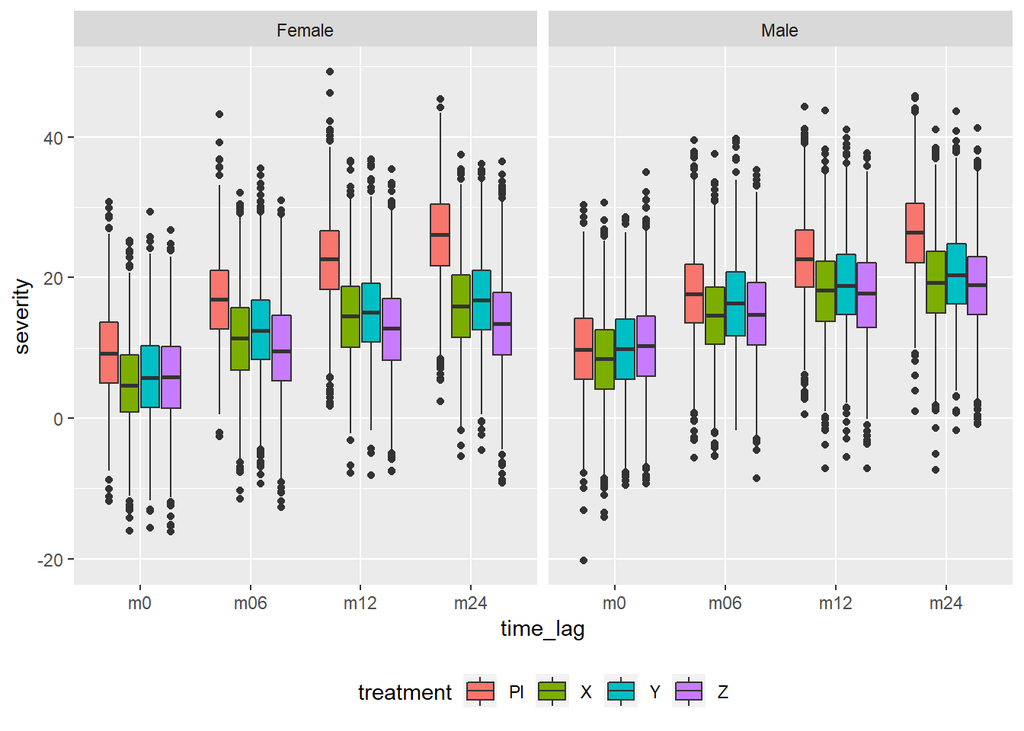

```r
ggplot(d_sim_long, aes(x=time_lag, y=severity, fill=treatment)) +
  geom_boxplot() +
  facet_grid(cols=vars(gender)) +
  theme(legend.position="bottom")
```

Or how the time that passed since diagnosis (*tsd*) is affecting *severity* in female and male patients:

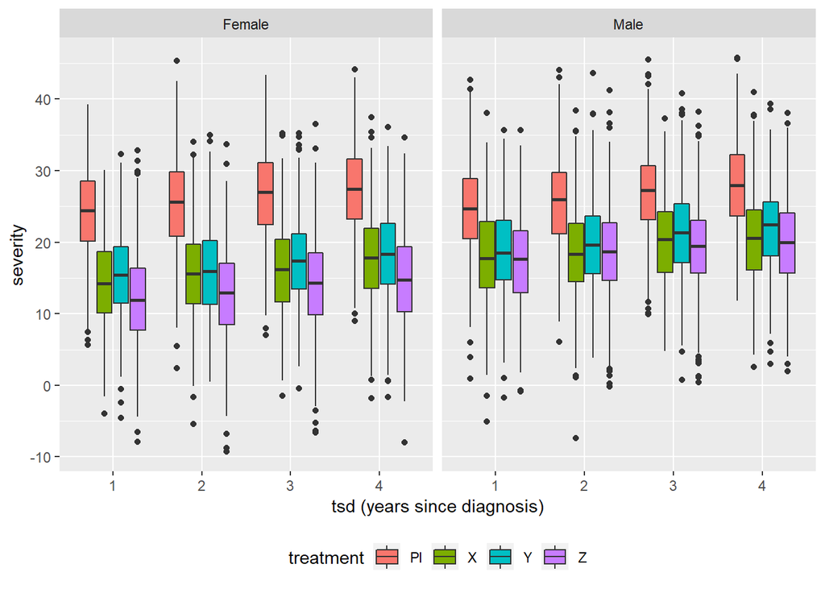

```r
ggplot(d_sim_long[d_sim_long$time_lag=="m24",], aes(x=as.factor(tsd), y=severity, fill=treatment)) +
  geom_boxplot() +
  theme(legend.position="bottom") +
  facet_grid(cols=vars(gender)) +
  labs(x = "tsd (years since diagnosis)")
```

Thank you for your time.